# Tölvuverkefni 1

Enar Kornelius Leferink (ekl4@hi.is) og Sverrir Arnórsson (sva19@hi.is)

1/11/2019

## Hluti 1

### a)

Gögn lesin inn og geymd í hlut sem ber upphafsstafi okkar:

```r
es <- read.table("husnaedi.txt", header=TRUE, sep=";", fileEncoding = "utf8")
```

### b)

Þrjú hverfi valin, Hagar/Melar, Laugarneshverfi/Vogar og Grafarvogur. Gamla taflan yfirskrifuð með aðeins þessum hverfum og flokkabreytur endurnefndar:

```r
hverfi <- c(72,100,130)
es <- filter(es, matssvaedi%in%hverfi)
es$matssvaedi <- factor(es$matssvaedi, levels=c(72,100,130), labels=c("Hagar/Melar", "Laugarneshverfi/Vogar", "Grafarvogur"))
```

### c)

Könnum hvort breytur séu rétt skilgreindar.

```r
print(str(es))
```

```
## 'data.frame':    3529 obs. of  4 variables:
##  $ nuvirdi   : int  24503 19969 30958 36386 24742 20182 26945 23800 33891 26073 ...
##  $ teg_eign  : Factor w/ 2 levels "Einbýlishús",..: 2 2 2 2 2 2 2 2 1 2 ...
##  $ matssvaedi: Factor w/ 3 levels "Hagar/Melar",..: 2 1 1 2 3 3 2 2 2 3 ...
##  $ ibm2      : num  100.8 78.6 123.2 119.4 112 ...
## NULL
```

Hér sést að allar breyturnar eru á réttu formi.

## Hluti 2

### a)

Mynd gerð sem sýnir fjölda eigna eftir hverfum og tegundum.

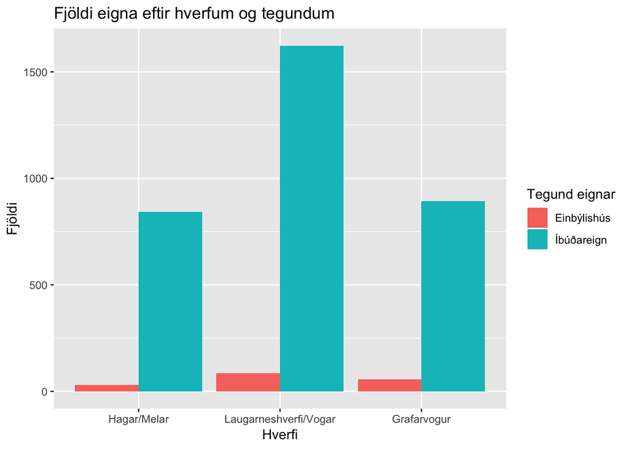

```r
ggplot(data = es, aes(fill=teg_eign, matssvaedi, labels=TRUE)) + geom_bar(position="dodge") + xlab("Hverfi") +ylab("Fjöldi") + labs(fill = "Tegund eignar", title = "Fjöldi eigna eftir hverfum og tegundum")
```

### b)

Mynd gerð sem er lýsandi fyrir stærðir einbýlishúsa eftir hverfum. Við ákváðum að leysa það með því að birta meðaltal eftir hverfum.

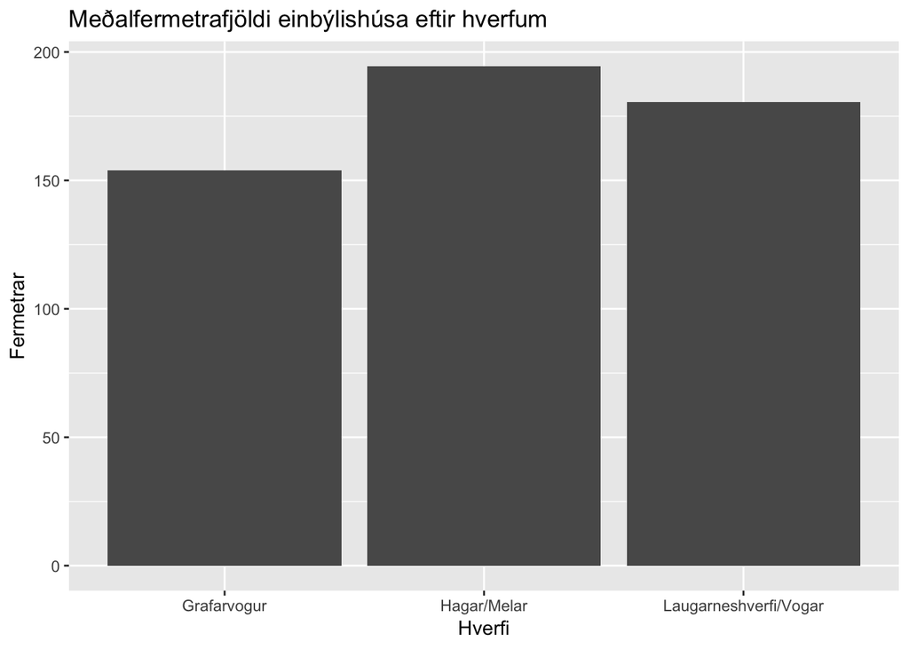

```r
einbyli <- filter(es, teg_eign== "Einbýlishús")

fm = c(3,2,1)
i=1
for (hverfi in c("Hagar/Melar", "Laugarneshverfi/Vogar", "Grafarvogur")) {
  fm[i]<-mean(filter(einbyli, matssvaedi == hverfi)$ibm2)
  i = i+1
}
m2 <- data.frame(matssvaedi = c("Hagar/Melar", "Laugarneshverfi/Vogar", "Grafarvogur"), fm)

ggplot(data = m2, aes(x=matssvaedi,y=fm)) + geom_col() + xlab("Hverfi") + ylab("Fermetrar") + labs(title="Meðalfermetrafjöldi einbýlishúsa eftir hverfum")
```

### c)

Búum til nýtt gagnasafn sem inniheldur aðeins íbúðir og teiknum mynd sem er lýsandi fyrir samband stærðar og verðs.

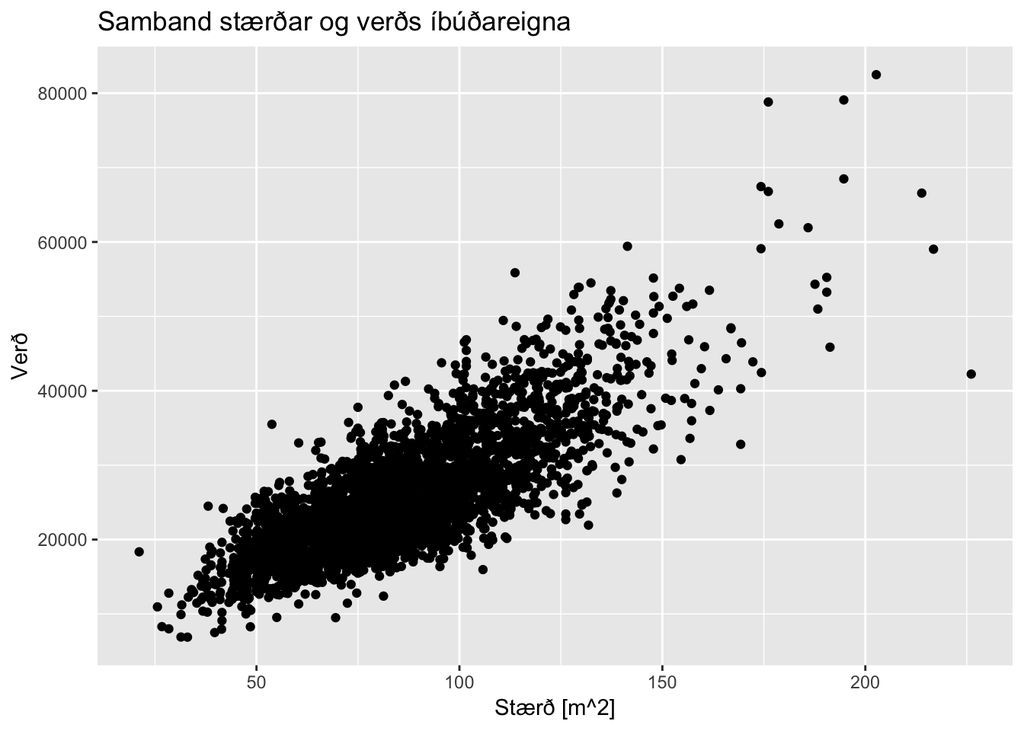

```r
ibudir<-filter(es, teg_eign == "Íbúðareign")
ggplot(data=ibudir, aes(x=ibm2,y=nuvirdi)) + geom_point() + labs(x="Stærð [m^2]", y="Verð", title="Samband stærðar og verðs íbúðareigna")
```

## Hluti 3

### a)

Búum til töflu með fjölda einbýlishúsa og íbúðareigna eftir hverfum.

```r
knitr::kable(table(es$teg_eign,es$matssvaedi), caption= "Fjöldi mismunandi eigna eftir hverfum")
```

Fjöldi mismunandi eigna eftir hverfum

|  | Hagar/Melar | Laugarneshverfi/Vogar | Grafarvogur |
| --- | --- | --- | --- |
| Einbýlishús | 31 | 84 | 57 |
| Íbúðareign | 842 | 1622 | 893 |

Önnur tafla gerð sem sýnir hlutfall íbúðaeigna af heildarfjölda eigna eftir hverfum.

```r
knitr::kable(round(prop.table(table(es$teg_eign,es$matssvaedi),margin=2), 3)[2,], caption="Hlutfall heildarfjölda eigna sem eru íbúðareignir",col.names = c("Hlutfall íbúða"))
```

Hlutfall heildarfjölda eigna sem eru íbúðareignir

|  | Hlutfall íbúða |
| --- | --- |
| Hagar/Melar | 0.964 |
| Laugarneshverfi/Vogar | 0.951 |
| Grafarvogur | 0.940 |

## b)

Lýsistærðir fyrir einbýlishús:

```r
eTafla <- einbyli %>% group_by(Matssvæði = matssvaedi)  %>% summarise(Min = min(nuvirdi), IQ1 = quantile(nuvirdi, 0.25), Meðaltal = mean(nuvirdi), IQ3 = quantile(nuvirdi, 0.75),Max = max(nuvirdi), Miðgildi = median(nuvirdi), Staðalfrávik = sd(nuvirdi))

knitr::kable(eTafla, caption = "Lýsistærðir fyrir einbýlishús")
```

Lýsistærðir fyrir einbýlishús

| Matssvæði | Min | IQ1 | Meðaltal | IQ3 | Max | Miðgildi | Staðalfrávik |
| --- | --- | --- | --- | --- | --- | --- | --- |
| Hagar/Melar | 24000 | 61785.00 | 76077.19 | 94027.00 | 148648 | 73694.0 | 27739.593 |
| Laugarneshverfi/Vogar | 7262 | 37321.25 | 53368.38 | 65041.25 | 121362 | 47806.5 | 22215.180 |
| Grafarvogur | 36409 | 46451.00 | 50490.30 | 53634.00 | 68821 | 49899.0 | 7098.036 |

## c)

Nýtt gagnasafn búið til sem inniheldur íbúðareignir af stærð frá og með $50m^2$ til og með $60m^2$.

```r
litlaribudir <- filter(ibudir, ibm2>=50, ibm2<=60)
```

Gerum töflu sem inniheldur meðalverð, miðgildi verðs og staðalfrávik þessara íbúða eftir hverfum.

```r
lTafla2 <- litlaribudir %>% group_by(Matssvæði = matssvaedi)  %>% summarise( Fjöldi = n(), Meðaltal = mean(nuvirdi), Miðgildi = median(nuvirdi), Staðalfrávik = sd(nuvirdi))
knitr::kable(lTafla2, caption = "Lýsistærðir fyrir litlar íbúðir")
```

Lýsistærðir fyrir litlar íbúðir

| Matssvæði | Fjöldi | Meðaltal | Miðgildi | Staðalfrávik |
| --- | --- | --- | --- | --- |
| Hagar/Melar | 139 | 19692.17 | 19446 | 3947.122 |
| Laugarneshverfi/Vogar | 153 | 18499.50 | 18180 | 3555.134 |
| Grafarvogur | 35 | 18754.66 | 18278 | 3000.538 |